# Analysis options: a complete walkthrough

Use the Get started examples for a first analysis. This guide shows which arguments to add when your question needs a different model, covariates, missing-data handling or inference method.

## Start with the defaults

```r
data(example_data)
result <- wsMed(
  data = example_data,
  M_C1 = c("A1", "B1"),
  M_C2 = c("A2", "B2"),
  Y_C1 = "D1",
  Y_C2 = "D2"
)
print(result)
```

```
#> wsMed analysis
#> Model: P | DE | Observations: 100
#> Effects:
#> wsMed all | raw scale | mc
#> 95% percentile intervals; 20000 joint draws; SE from effect draws
#> Condition contrast: C2 - C1
#>                                        Estimate Std. Error  CI lower  CI upper
#> cp: Direct effect                     -0.031795   0.017000 -0.064525  0.001864
#> indirect_1: M1                         0.001311   0.003208 -0.004601  0.008917
#> indirect_2: M2                        -0.001120   0.002570 -0.007617  0.003084
#> total_indirect: Total indirect effect  0.000191   0.004111 -0.008172  0.008783
#> total: Total effect                   -0.031604   0.017015 -0.064740  0.001839
#> Inference draws: 20000 retained of 20000 ; 0 excluded before effect extraction.
#> Use as.data.frame() for the full-precision table and metadata.
#> Post-fit admissibility: 1 of 1 ; excluded rows: 0
```

The default is parallel mediation with Monte Carlo inference, 20,000 draws, 95% CIs and unstandardized output. Listwise deletion is the default missing-data strategy; the example data are complete. Later calls keep these defaults unless an argument is explicitly changed.

## Paired variables

Each row represents one participant. Match each mediator’s condition 1 and condition 2 measurements by position in `M_C1` and `M_C2`. `Y_C1` and `Y_C2` identify the outcome pair. Differences are always **condition 2 minus condition 1**.

| Construct | Condition 1 | Condition 2 | Role |
| --- | --- | --- | --- |
| A | `A1` | `A2` | First mediator (`M1`) |
| B | `B1` | `B2` | Second mediator (`M2`) |
| D | `D1` | `D2` | Outcome (`Y`) |

Outcomes, mediators and within-subject covariates are analyzed as continuous numeric variables. Binary and multicategory variables can be between-subject covariates or moderators; use unordered factors with explicit levels. See categorical predictors.

## Choose the mediator structure

### Predefined models

| `form` | Structure |
| --- | --- |
| `"P"` (default) | Parallel mediation |
| `"CN"` | Serial mediation; each mediator predicts every later mediator |
| `"CP"` | Serial-parallel mediation; M1 predicts the remaining mediators |
| `"PC"` | Parallel-serial mediation; the remaining mediators predict M1 |

The diagrams show the four predefined structures. Each includes condition effects on every mediator and the outcome, and paths from every mediator to the outcome. The connections among mediators distinguish the models.

**P: Parallel**

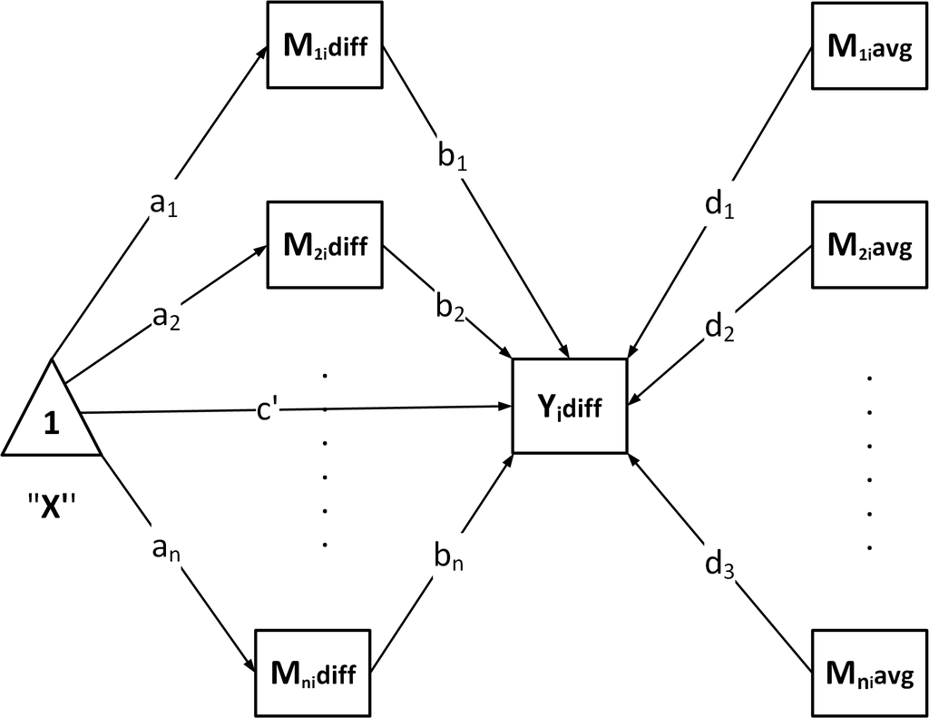

No directed connections among mediators. Model equations.

**CN: Serial**

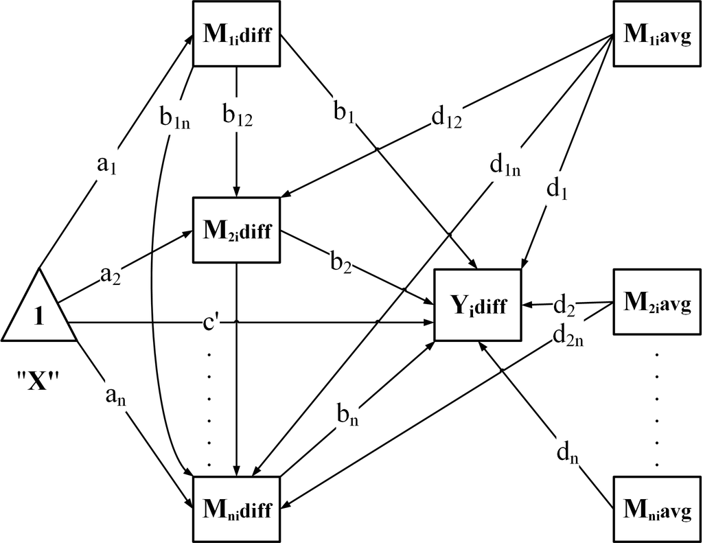

Each earlier mediator predicts every later mediator. Model equations.

**CP: Serial-parallel**

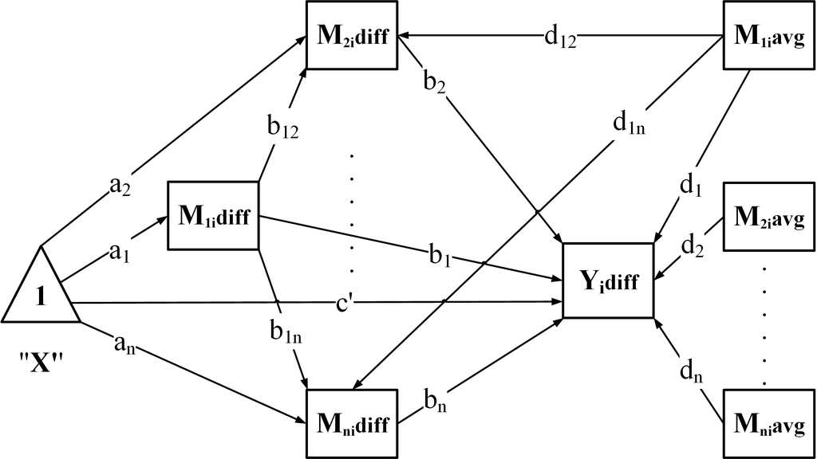

M1 predicts M2, M3, and so on. Model equations.

**PC: Parallel-serial**

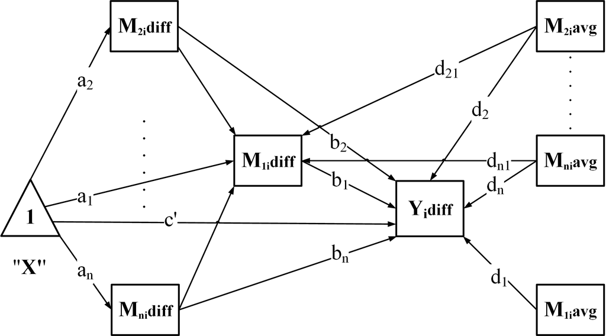

M2, M3, and so on predict M1. Model equations.

Click a diagram to enlarge it. In these difference-score diagrams, `diff` denotes condition 2 minus condition 1 and `avg` denotes the centered average; the triangle represents the constant used to estimate condition effects.

For example, change only `form` to fit a serial model:

```r
serial <- wsMed(
  data = example_data,
  M_C1 = c("A1", "B1"),
  M_C2 = c("A2", "B2"),
  Y_C1 = "D1",
  Y_C2 = "D2",
  form = "CN"
)
print(serial)
```

Choose mediator order from the research design. The model articles show the parallel, serial, serial-parallel and parallel-serial equations and diagrams.

### User-defined models

Use `form = "UD"` when you want to specify the mediator connections yourself. Mediator labels follow the order in `M_C1` and `M_C2`: in the call below, `M1` is A, `M2` is B, and `M3` is C. `Y` is the outcome pair D1/D2. In `paths`, write one arrow per string using these labels:

```r
custom_paths <- c(
  "M1 -> M3",  # A predicts C
  "M3 -> Y",   # C predicts the outcome
  "M2 -> Y"    # B predicts the outcome
)
```

Pass this vector to `wsMed()`; all other settings keep their defaults:

```r
custom <- wsMed(
  data = example_data,
  M_C1 = c("A1", "B1", "C1"),
  M_C2 = c("A2", "B2", "C2"),
  Y_C1 = "D1",
  Y_C2 = "D2",
  form = "UD",
  paths = custom_paths
)
print(custom)
```

```
#> wsMed analysis
#> Model: UD | DE | Observations: 100
#> Effects:
#> wsMed all | raw scale | mc
#> 95% percentile intervals; 20000 joint draws; SE from effect draws
#> Condition contrast: C2 - C1
#>                                        Estimate Std. Error  CI lower  CI upper
#> cp: Direct effect                     -3.00e-02   1.68e-02 -6.31e-02  2.90e-03
#> indirect_1_3: M1 -> M3                -2.25e-05   3.63e-04 -8.44e-04  7.36e-04
#> indirect_2: M2                        -1.40e-03   2.75e-03 -8.43e-03  2.98e-03
#> indirect_3: M3                        -1.85e-04   2.17e-03 -5.11e-03  4.38e-03
#> total_indirect: Total indirect effect -1.60e-03   3.55e-03 -9.76e-03  4.94e-03
#> total: Total effect                   -3.16e-02   1.69e-02 -6.48e-02  1.55e-03
#> Inference draws: 20000 retained of 20000 ; 0 excluded before effect extraction.
#> Use as.data.frame() for the full-precision table and metadata.
#> Post-fit admissibility: 1 of 1 ; excluded rows: 0
```

Only the specified mediator connections are fitted. For example, `M1 -> Y` is absent here; add that string to `custom_paths` if the model should include it. Paths from the condition to every mediator and the direct condition-to-outcome path are added automatically, so do not include `X` in `paths`.

The arrows must not form a cycle, and at least one must end at `Y`. The worked UD example explains these rules and shows how the specified arrows determine the indirect effects.

To add moderation, keep `custom_paths` and add `W = "D3"` and `MP = c("b_1_3", "b3")`. This selects the M1-to-M3 and M3-to-outcome slopes for moderation by D3. Unlike `paths`, `MP` takes coefficient labels, not arrow strings. See the UD moderation example for the full call, path-label choices, and conditional results.

## Add optional model components

### Covariates

Use `C_C1` and `C_C2` for paired within-subject covariates and `C` for between-subject covariates. Their measurements remain in the same wide dataset:

```r
adjusted <- wsMed(
  data = example_data,
  M_C1 = c("A1", "B1"),
  M_C2 = c("A2", "B2"),
  Y_C1 = "D1",
  Y_C2 = "D2",
  C_C1 = "C1",
  C_C2 = "C2",
  C = "D3"
)
print(adjusted)
```

### Moderators

Use `W` for the moderator column and `MP` for the paths to moderate. In the parallel model, `b1` and `b2` are the mediator-to-outcome difference slopes:

```r
moderated <- wsMed(
  data = example_data,
  M_C1 = c("A1", "B1"),
  M_C2 = c("A2", "B2"),
  Y_C1 = "D1",
  Y_C2 = "D2",
  W = "D3",
  MP = c("b1", "b2")
)
print(moderated)
plot(moderated)
```

Moderator main effects enter the difference equations automatically. For a continuous moderator, the default report uses the centering reference, whereas the default plot shows curves over the observed range. These two displays answer different questions. The second Get started example shows both outputs. Use `at` only to request particular raw moderator values.

For a categorical moderator, declare an unordered factor, choose its reference level, and pass its column name to `W`. See the categorical example.

## Missing data and confidence intervals

### Choose a missing-data strategy

| `Na` | Data handling | Available CI methods |
| --- | --- | --- |
| `"DE"` (default) | Listwise deletion | Monte Carlo or bootstrap |
| `"FIML"` | Full-information maximum likelihood | Monte Carlo or bootstrap |
| `"MI"` | Multiple imputation | Monte Carlo |

To illustrate these choices, remove a few simulated post-condition measurements:

```r
incomplete <- example_data
incomplete$A2[1:5] <- NA
incomplete$D2[6:10] <- NA
```

Add `Na = "FIML"` when you want FIML:

```r
fiml_result <- wsMed(
  data = incomplete,
  M_C1 = c("A1", "B1"),
  M_C2 = c("A2", "B2"),
  Y_C1 = "D1",
  Y_C2 = "D2",
  Na = "FIML"
)
print(fiml_result)
```

Use `Na = "MI"` for multiple imputation. The default uses five predictive mean matching imputations for the numeric variables in this example:

```r
mi_result <- wsMed(
  data = incomplete,
  M_C1 = c("A1", "B1"),
  M_C2 = c("A2", "B2"),
  Y_C1 = "D1",
  Y_C2 = "D2",
  Na = "MI"
)
print(mi_result)
```

For finer control, `mi_args` accepts imputation settings; for example, `mi_args = list(m = 20)` requests 20 imputations. Select the imputation method and number of imputations for your data and analysis.

MI imputes the original measurements before constructing analysis variables within each completed dataset. FIML handles missing analysis variables during fitting, after differences, averages and interactions have been constructed. FIML requires categorical predictors to be fully observed.

Choose a strategy that is appropriate for the missing-data assumptions and variable roles. With moderation, default main-effects imputation may not preserve the substantive interactions; see model-compatible imputation.

### Choose the inference method

Monte Carlo is the default. To combine FIML with bootstrap CIs, specify both `Na` and `ci_method`. This executed example uses the incomplete data above and the default 2,000 bootstrap replicates:

```r
boot_result <- wsMed(
  data = incomplete,
  M_C1 = c("A1", "B1"),
  M_C2 = c("A2", "B2"),
  Y_C1 = "D1",
  Y_C2 = "D2",
  Na = "FIML",
  ci_method = "bootstrap"
)
print(boot_result)
```

```
#> wsMed analysis
#> Model: P | FIML | Observations: 100
#> Effects:
#> wsMed all | raw scale | bootstrap
#> 95% percentile intervals; 2000 joint draws; SE from effect draws
#> Condition contrast: C2 - C1
#>                                        Estimate Std. Error  CI lower  CI upper
#> cp: Direct effect                     -0.028639   0.017200 -0.062908  0.005576
#> indirect_1: M1                        -0.000828   0.003209 -0.008216  0.005280
#> indirect_2: M2                        -0.001846   0.003449 -0.010600  0.003383
#> total_indirect: Total indirect effect -0.002673   0.004737 -0.013825  0.005631
#> total: Total effect                   -0.031313   0.017464 -0.066589  0.003270
#> Inference draws: 2000 retained of 2000 ; 0 excluded before effect extraction.
#> Use as.data.frame() for the full-precision table and metadata.
#> Post-fit admissibility: 1 of 1 ; excluded rows: 0
```

When one member of a measurement pair is missing, its difference and average are missing too. FIML handles these constructed variables during fitting; the observed member of the original pair is not separately included in this model. The bootstrap resamples participant rows of the constructed analysis data, retaining the within-participant pairing and fitting each sample with FIML. For complete data or listwise deletion, omit `Na = "FIML"` from this call.

`R` controls Monte Carlo draws, `bootstrap` controls bootstrap replicates, and `alpha` controls the confidence level as `1 - alpha`. `seed` and `iseed` control the Monte Carlo and bootstrap random draws, respectively. `ci_method = "both"` retains both inference engines; `print()` then reports them separately. MI currently supports Monte Carlo only.

## Standardized effects

The default output is unstandardized. Add `standardized = TRUE` to the analysis to save standardized reporting as its default, or request it for one summary:

```r
summary(
  result,
  standardized = TRUE
)
```

```
#> wsMed statistical summary
#> Model: P | Missing: DE | Observations: 100
#> Effects:
#> wsMed all | marginal scale | mc
#> 95% percentile intervals; 20000 joint draws; SE from effect draws
#> Condition contrast: C2 - C1
#> Standardization: effect / marginal model-implied SD(D2 - D1); condition contrast is unscaled.
#> Plug-in marginal outcome-difference SD: 0.169239
#> The denominator is not a moderator-specific conditional SD.
#>                                       Estimate Std. Error CI lower CI upper
#> cp: Direct effect                     -0.18787    0.10051 -0.38202  0.01096
#> indirect_1: M1                         0.00775    0.01858 -0.02674  0.05159
#> indirect_2: M2                        -0.00662    0.01480 -0.04360  0.01801
#> total_indirect: Total indirect effect  0.00113    0.02378 -0.04770  0.05070
#> total: Total effect                   -0.18674    0.10054 -0.38189  0.01043
#> Inference draws: 20000 retained of 20000 ; 0 excluded before effect extraction.
#> Use as.data.frame() for the full-precision table and metadata.
#>
#> Path coefficients:
#>    Estimate Std. Error CI lower CI upper
#> cp  -0.1879     0.1005  -0.3820   0.0110
#> b1  -0.0501     0.0972  -0.2381   0.1427
#> d1  -0.0751     0.1012  -0.2724   0.1253
#> b2  -0.0821     0.0973  -0.2710   0.1092
#> d2  -0.0438     0.1014  -0.2392   0.1566
#> a1  -0.1546     0.1026  -0.3598   0.0419
#> a2   0.0806     0.1013  -0.1133   0.2817
#> Post-fit admissibility: 1 of 1 ; excluded rows: 0
#> Tables: $effects, $coefficients; analysis settings: $info.
```

Changing the reporting scale does not fit a new model. Standardized CIs propagate uncertainty in the coefficients and model-implied scales; they are not obtained by dividing the unstandardized CI endpoints by a single fitted SD. See standardized effects.

## Inspect and present the results

```r
summary(result)
```

```
#> wsMed statistical summary
#> Model: P | Missing: DE | Observations: 100
#> Effects:
#> wsMed all | raw scale | mc
#> 95% percentile intervals; 20000 joint draws; SE from effect draws
#> Condition contrast: C2 - C1
#>                                        Estimate Std. Error  CI lower  CI upper
#> cp: Direct effect                     -0.031795   0.017000 -0.064525  0.001864
#> indirect_1: M1                         0.001311   0.003208 -0.004601  0.008917
#> indirect_2: M2                        -0.001120   0.002570 -0.007617  0.003084
#> total_indirect: Total indirect effect  0.000191   0.004111 -0.008172  0.008783
#> total: Total effect                   -0.031604   0.017015 -0.064740  0.001839
#> Inference draws: 20000 retained of 20000 ; 0 excluded before effect extraction.
#> Use as.data.frame() for the full-precision table and metadata.
#>
#> Path coefficients:
#>    Estimate Std. Error CI lower CI upper
#> cp -0.03180    0.01700 -0.06453  0.00186
#> b1 -0.04834    0.09555 -0.23422  0.13918
#> d1 -0.06905    0.09508 -0.25772  0.11690
#> b2 -0.07732    0.09387 -0.26459  0.10461
#> d2 -0.03676    0.08692 -0.20641  0.13385
#> a1 -0.02712    0.01772 -0.06242  0.00737
#> a2  0.01448    0.01796 -0.02033  0.04929
#> Post-fit admissibility: 1 of 1 ; excluded rows: 0
#> Tables: $effects, $coefficients; analysis settings: $info.
```

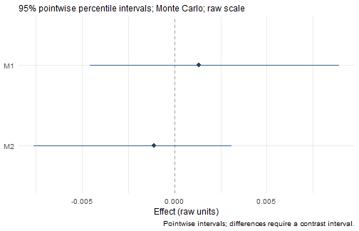

```r
plot(result)
```

Use `print(result)` for the core report and `summary(result)` for a structured statistical summary. Their default displays can be read directly. Numerical extraction, selected moderator values and export are optional next steps in Read and export results.

For generated model syntax, use `printGM(result)`. For separate model specification, fitting, inspection and inference, use the staged workflow.

## Manuscript data

The package also includes the empirical dataset used in the paper:

```r
data(wsmed_examples)
dim(wsmed_examples)
```

```
#> [1] 123  14
```

It contains 123 intervention-group participants and retains the original missing values. Its help page documents the study, processing, variable definitions and license. The examples on this page use simulated data to teach analysis choices; the paper’s replication materials record the full settings and computing environment for its numerical results.